# Shriveling World Cleaning cities data

## Check Geometry

### Plot the geometries

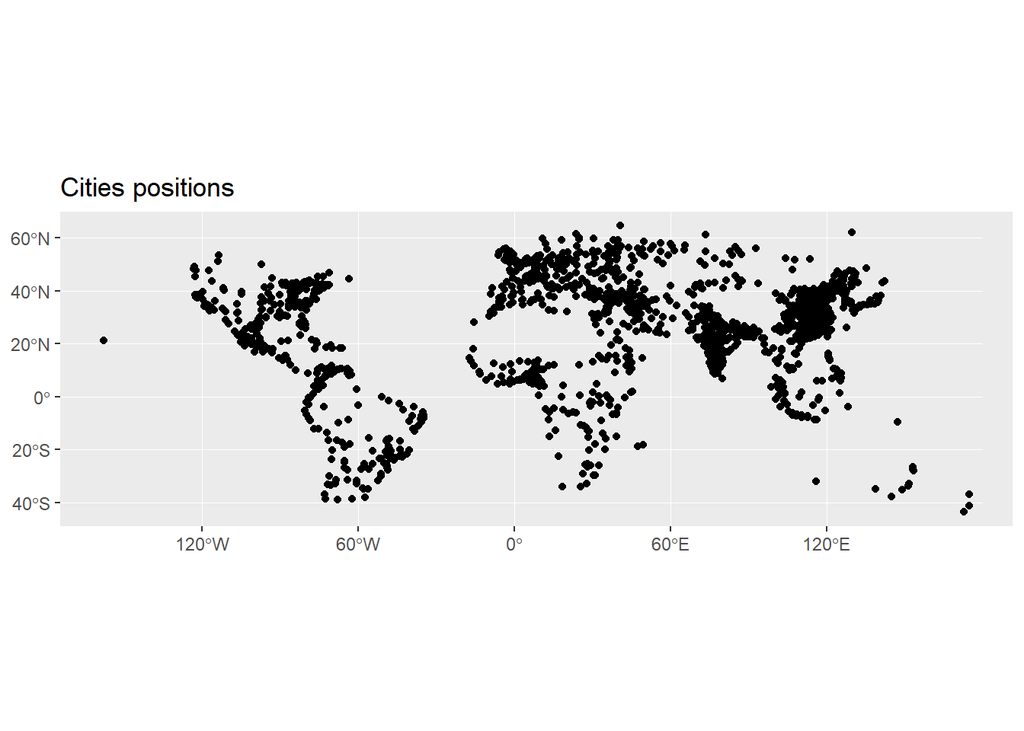

```r
ggplot(cities_df) +
  geom_sf()+
  ggtitle("Cities positions")
```

### Using mapview

This will allow to display a basemap so we can check if cities are correctly placed.

```r
m <- mapview(cities_df, map.types="CartoDB.Positron")
#mapshot(m, file = paste0(getwd(), "figures/cities_example.png"))

#mapshot(m, file = paste0(here("example", "datas","figures","cities_example.png")))
m
```

[interactive chart not shown]

Constants: Here we will fix the limit under which we want to find close cities.

```r
buffer_size = set_units(20000, 'm') # 20 km
```

## Simplification of the dataset

We don’t need all the columns now so we can simplified the dataset.

```r
cities_df_simplified <- cities_df %>%
  select("cityCode")

head(cities_df_simplified)
```

| cityCode | geometry |
| --- | --- |
| 21137 |  |
| 20001 |  |
| 20002 |  |
| 20003 |  |
| 20005 |  |
| 20009 |  |

## Distance matrix creation

As WGS84 is in spherical geometry, we will need to use the *st_distance()* function with the capabilities provided by {lwgeom}.

Source: https://stackoverflow.com/questions/54294484/rstats-how-to-convert-kilometers-into-arc-degrees-in-order-to-create-buffers-w/54296072#54296072

```r
dist_mat <- st_distance(cities_df_simplified)

# Create a Truth matrix when 0 < distance < 200000 meters
#

truth_matrix <- dist_mat < buffer_size & dist_mat > set_units(0,'m')


# Put cities index as row and column names
dimnames(truth_matrix) <- list(cities_df$cityCode, cities_df$cityCode)

# fusion de la matrice pour créer une colonne pour chaque identifiant
# les valeur sont filtrées pour ne garder que les valeurs posiitives.
# source: https://stackoverflow.com/questions/32024620/subset-data-frame-to-get-rowname-colname-and-value

extraction <- subset(melt(truth_matrix), value ==1)
head(extraction)
```

|  | Var1 | Var2 | value |
| --- | --- | --- | --- |
| 30283 | 20073 | 20063 | TRUE |
| 40363 | 20063 | 20073 | TRUE |
| 114378 | 20888 | 204024 | TRUE |
| 116058 | 204024 | 20888 | TRUE |
| 134610 | 20222 | 20183 | TRUE |
| 216930 | 20183 | 20222 | TRUE |

*st_distance()* returns a matrix of distances between the cities. Then we check if this distance is between 0 and 20000 meters (TRUE) or not (FALSE)

*Var1* and *Var2* are Origin and Destination city codes.

# Create pairs

The pairs are created from the extraction, by creating a new id unique ID *unique_order* based on the size of the city codes. The doubles are cleared.

```r
vars <- c(cityCodeV1 = "Var1", cityCodeV2 ="Var2") # rename columns
pairs <- extraction %>%
  rowwise() %>%
  mutate(unique_order =
           paste(min(Var1, Var2),
                 max(Var1, Var2), sep = '-')) %>%
  distinct(unique_order, .keep_all = TRUE) %>%
  rename(!!vars)
```

To the pairs are join data from the origin city like th geometry this is done to visualize their position on the map.

```r
pairs_geom <-  pairs %>%
  left_join(cities_df, by =  c("cityCodeV1" = "cityCode")) %>%
  st_as_sf()
head(pairs_geom)
```

| cityCodeV1 | cityCodeV2 | value | unique_order | index | countryCode | countryName | urbanAgglomeration | radius | yearMotorway | yearHST | geometry |
| --- | --- | --- | --- | --- | --- | --- | --- | --- | --- | --- | --- |
| 20073 | 20063 | TRUE | 20063-20073 | 24 | 32 | Argentina | Resistencia | NA | NA | NA |  |
| 20888 | 204024 | TRUE | 20888-204024 | 69 | 204 | Benin | Cotonou | NA | NA | NA |  |
| 20222 | 20183 | TRUE | 20183-20222 | 129 | 76 | Brazil | Vale do Aço | NA | NA | NA |  |
| 22974 | 20406 | TRUE | 20406-22974 | 1550 | 840 | United States of America | Detroit | NA | NA | NA |  |
| 23792 | 23586 | TRUE | 23586-23792 | 503 | 156 | China | Xinzheng | NA | NA | NA |  |
| 20779 | 23595 | TRUE | 20779-23595 | 538 | 156 | China | Yuyao | NA | NA | NA |  |

```r
m <- mapview(pairs_geom, map.types="CartoDB.Positron")
#mapshot(m, file = paste0(getwd(), "figures/pairs_cities.png"))
m
```

[interactive chart not shown]

# Order by population

As we want to remove the smallest city and add its population to the biggest, we first need to had population of each city using its city code.

```r
# Create a simple df with only cityCode and 2015 population
pop2015 <- population %>%
  select(cityCode, pop2015)

pairs_pop <- pairs_geom %>%
  left_join(pop2015, by = c("cityCodeV1" = "cityCode")) %>%
  rename(v1_pop2015 = pop2015) %>%
  left_join(pop2015, by =c("cityCodeV2" = "cityCode")) %>%
  rename(v2_pop2015 = pop2015)
head(pairs_pop)
```

| cityCodeV1 | cityCodeV2 | value | unique_order | index | countryCode | countryName | urbanAgglomeration | radius | yearMotorway | yearHST | v1_pop2015 | v2_pop2015 | geometry |
| --- | --- | --- | --- | --- | --- | --- | --- | --- | --- | --- | --- | --- | --- |
| 20073 | 20063 | TRUE | 20063-20073 | 24 | 32 | Argentina | Resistencia | NA | NA | NA | 414 | 384 |  |
| 20888 | 204024 | TRUE | 20888-204024 | 69 | 204 | Benin | Cotonou | NA | NA | NA | 682 | 757 |  |
| 20222 | 20183 | TRUE | 20183-20222 | 129 | 76 | Brazil | Vale do Aço | NA | NA | NA | 497 | 5716 |  |
| 22974 | 20406 | TRUE | 20406-22974 | 1550 | 840 | United States of America | Detroit | NA | NA | NA | 3639 | 315 |  |
| 23792 | 23586 | TRUE | 23586-23792 | 503 | 156 | China | Xinzheng | NA | NA | NA | 384 | 367 |  |
| 20779 | 23595 | TRUE | 20779-23595 | 538 | 156 | China | Yuyao | NA | NA | NA | 596 | 1303 |  |

Then we create a new data frame where we keep the citycode of the biggest city and the sum of the population of the 2 cities.

It was first created with a for loop to test the algorithme then implemented using the function *transmute()* from the package {dplyr} for educationnal reasons.

## With a loop

```r
## Keep as an example, does the same as the next block code
to_clean_df <- setNames(data.frame(matrix(ncol = 2, nrow = dim(pairs_pop)[1])),c("to_keep", "to_keep_pop"))
# For each row, determine which city is the biggest and adds the two cities population
for (i  in 1:dim(pairs_pop)[1]) {


  if(pairs_pop$v1_pop2015[i] > pairs_pop$v2_pop2015[i]){
    to_clean_df$to_keep[i] = pairs_pop$cityCodeV1[i]
    to_clean_df$to_keep_pop[i] = pairs_pop$v1_pop2015[i] + pairs_pop$v2_pop2015[i]

  }
  else
  {
    to_clean_df$to_keep[i] = pairs_pop$cityCodeV2[i]
    to_clean_df$to_keep_pop[i] = pairs_pop$v1_pop2015[i] + pairs_pop$v2_pop2015[i]
  }

}
to_clean_df
```

## With *transmute()*

```r
clean_df <- transmute(pairs_pop,
              to_keep = if_else(v1_pop2015 > v2_pop2015, cityCodeV1, cityCodeV2),
              to_keep_pop = v1_pop2015 + v2_pop2015)

citycode_to_keep <- unique(clean_df$to_keep) # 48 cities
head(citycode_to_keep)
```

```
## [1]  20073 204024  20183  22974  23792  23595
```

At the end of this, we have extracted from the pairs a list of cities to keep.

# Formating and writing output

Going back to the *extraction* dataframe, we create a dataframe of rejected cities with the *antijoin()* function.

From the dataframe of all the cities we perform an antijoin again with the rejected cities to keep only the cities that are not rejected.

```r
# list of cities to keep
## all cities - pairs + cities to keep

# Many cities to delete
length(unique(extraction$Var1)) - length(citycode_to_keep )
```

```
## [1] 43
```

```r
### list of rejected cities
rejected_cities <- extraction %>% # from all cities of the truth matrix
  distinct(Var1) %>% # keep unique citycode (Var1 == Var2)
  anti_join(clean_df, by = c("Var1" = "to_keep")) %>% # remove cities we want to keep
  rename(cityCode = Var1) # change column name for next step


### list of all cities without rejected
# cities antijoin with rejected
# list of citycode

## filter origal data (without geom) to keep file structure
cities_out <- cities %>%
  anti_join(rejected_cities, by = "cityCode") # remove rejected cities

# reduced data set for tests
china_out <- cities_out %>%
  filter(countryName == "China")

dim(cities_out) # 1638 cities, 43 out, 1681 total
```

```
## [1] 1638   10
```

```r
##
```

Finally we write the new csv files.

```r
write_csv(cities_out, "to_drop_in_app/cleaned_cities.csv")
write_csv(china_out, "to_drop_in_app_sample/cleaned_cities_China.csv")
```

# Issues

## Distance criteria

We choose a 20 km distance, maybe there is something more robust to get that distance.

## Cleaning Population and transport networks

The Population and network files still contains data from removed cities. It will be good to clean them as well.